# Loan Data from Prosper

by Samuel Carleial

23 July 2018

========================================================

### Abstract

Here, I explore and summarize data collected on loans given by [Prosper](https://www.prosper.com/). The investigated dataset is comprised of over 110,000 observations from 2005-2014, and has 81 variables. This project is part of the Udacity Data Analyst Nanodegree 2018.

### Introduction

People borrow a credit in order to acquire money in a short time, which otherwise would not have been easily available if they worked or had another paid activity. In finance, a *loan* is the lending of money by one or more individuals, organizations, and/or other entities to other individuals, organizations etc. The recipient (i.e., the borrower) incurs a debt, and is usually liable to pay interest on that debt until it is repaid, and also to repay the principal amount borrowed (source: [Wikipedia](https://en.wikipedia.org/wiki/Loan)).

Therefore, loan data may show us interesting society behaviors regarding the use of money. Further, it may give us insights into economic situation on a population and also even help us think about good politics that might support people in need.

The dataset in question gathers lots of information on loans, including personal information, loan characteristics and status, and observation information (such as date and identification numbers).

### What might influence loans?

We may have a couple of directions to use for exploring this dataset. It might be interesting, for instance, to investigate whether loans are related to annual timepoints (when it was created or paid-off). Or whether social data is related to the loan (amount, status or duration). There is no right or wrong way, but previous expectations and ideas are definitely helpful. So, let us get started!

### Analysis

Dataset dimensions:

```
## [1] 113937     81
```

Dataset number of missing values:

```
## [1] 1078519
```

> **Note**: The dataset is huge (> 100,000 observations), with many variables (> 80). It would be better to select variables of importance, disregarding the ones that do not seem interesting for the moment, such as “ListingKey” or “GroupKey”. For many of the variables above, we notice that there are missings or NAs. Although vast, descriptive statistics using summary() function (*not shown here for the sake of conciseness) gave me an impression of the nature and type of data.

So, let us first take a look at a couple of variables related to loan and then look at the characteristics of the borrowers.

Variables of interest in this analysis:

```r
variables_of_interest <- c(
                           "ListingCategory..numeric.", # loan characteristics
                           "LoanStatus",
                           "LoanOriginalAmount",
                           "LoanOriginationDate",
                           "LoanOriginationQuarter",
                           "Term",
                           "LoanMonthsSinceOrigination",

                           "BorrowerRate",              # borrower data
                           "BorrowerAPR",
                           "EmploymentStatus",
                           "IncomeRange",
                           "StatedMonthlyIncome",
                           "IncomeVerifiable",
                           "BorrowerState",
                           "Recommendations",
                           "CurrentDelinquencies",
                           "AmountDelinquent",

                           "EstimatedEffectiveYield",  # lender data
                           "EstimatedReturn"
                           )
```

```r
# subset data with only variables of interest
subset <- data %>%
          select(variables_of_interest) %>%
          sample_n(1000)
```

# Univariate Plots Section

## Loan

To understand better the loan aspects, let us see which type of loans and which characterisitcs of them are in the data. The variables I choose are plotted below.

Loan variables:

```
## [1] "type"     "status"   "amount"   "date"     "quarter"  "term"
## [7] "duration"
```

```
##    Min. 1st Qu.  Median    Mean 3rd Qu.    Max.
##    1000    4000    6500    8337   12000   35000
```

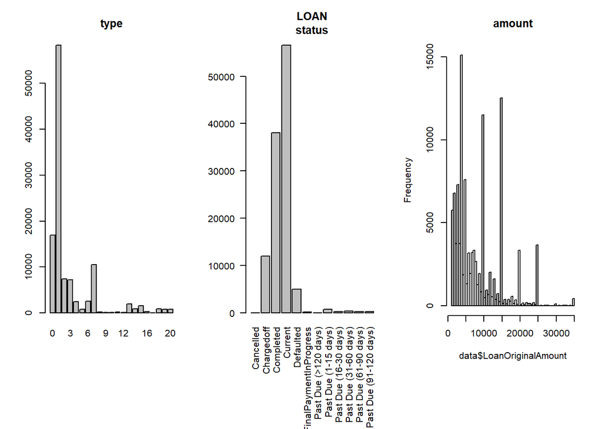

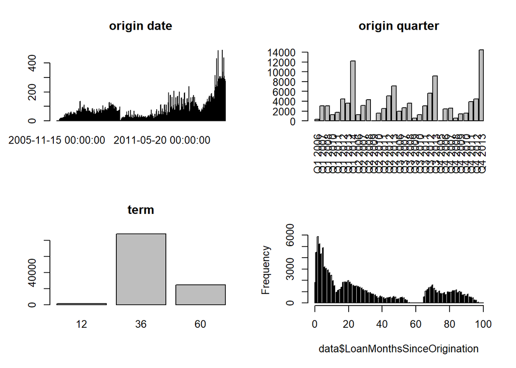

## Borrower

To understand better the aspects of whom made the loans, let us look at borrower characteristics. The variables I selected are plotted below.

Borrower variables:

```
##  [1] "rate"          "apr"           "job"           "income"
##  [5] "income_stated" "income_true"   "state"         "recomm"
##  [9] "delinq_nr"     "delinq_$"
```

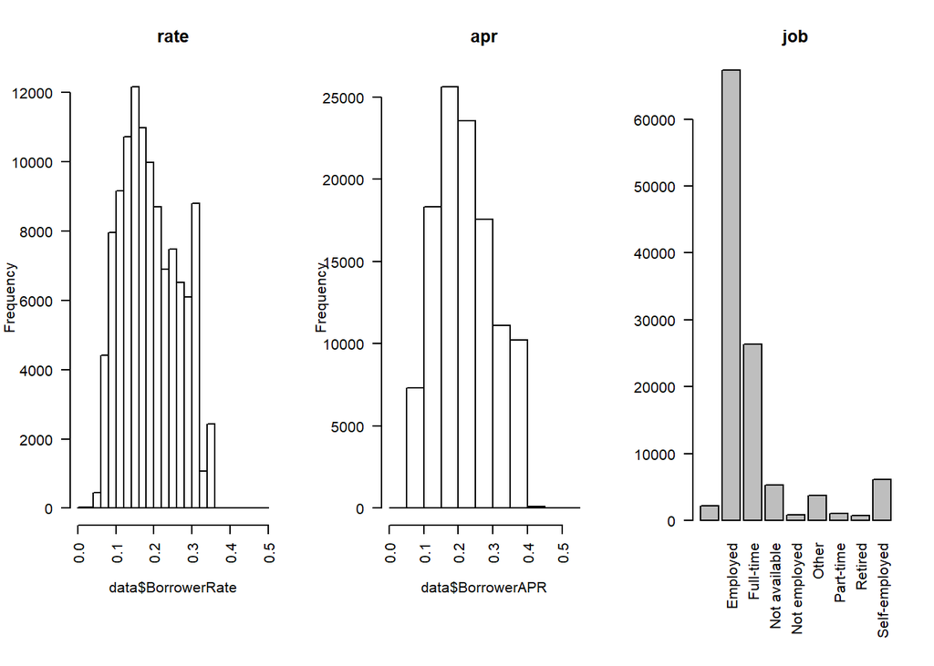

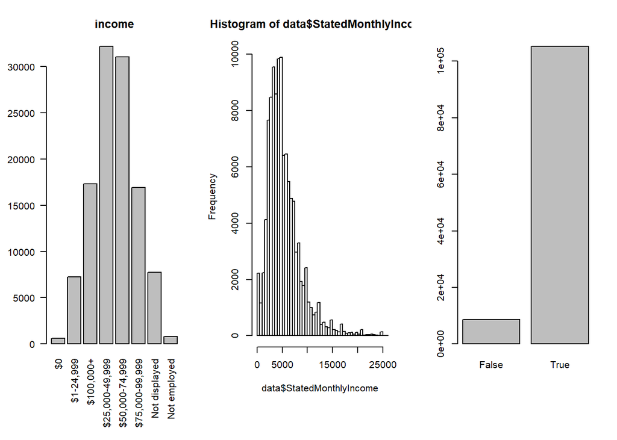

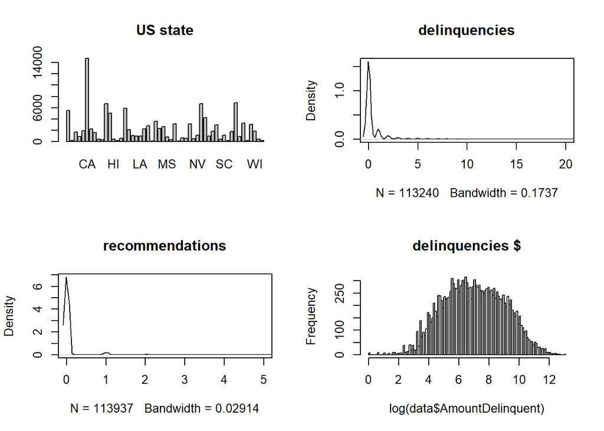

Most common states (frequency):

```
##
##    CA    TX    NY    FL    IL          GA    OH    MI    VA    NJ
## 14717  6842  6729  6720  5921  5515  5008  4197  3593  3278  3097
```

## Lender

To understand better the aspects of whom provided the loans, let us look at lender characteristics. The variables I selected are plotted below.

Lender variables:

```
## [1] "yield"  "return"
```

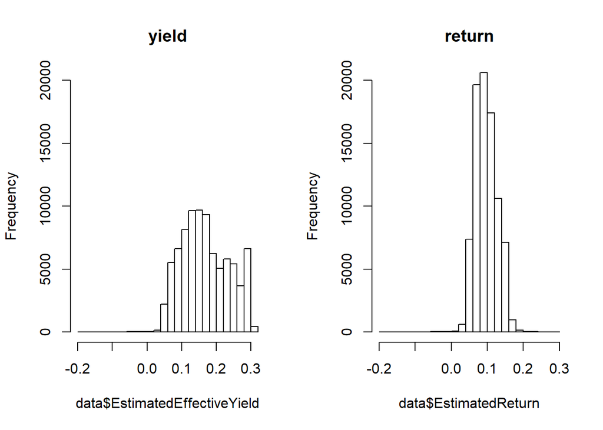

> **Notes on lenders**
1. The profits of lenders are rates of appr. 0.1-0.2. Notice that after 2009 only!

# Univariate Analysis Overview

### Dataset structure

Data dimensions: 81 variables * >100k obs.  
The dataset is comprised of many variables, but basically we can split it into two main groups: loan and borrower attributes. Lenders might additionally be considered.

### Main feature of interest in the dataset

We have socio-demographic features that might be related to the amount, duration and other loan characteristics.

### Additional features that might be of interest and influence loans

Borrower extra individual information, namely “recommendations” and “delinquencies” might be positive or detrimental to borrowers, when applying for a loan. Therefore, these effects might be included in the analysis.

### Unusual observations or variable distributions

Overview of univariate data showed in many cases distributions with patterns. For example, loan amount and duration (decreasing trend). Normal distributions were also found, such as in income range. I also found cases of outliers, such as in “delinquencies” (few values close to 15) and extreme frequencies in some variables, such as with loan amounts. I did not transform the data, but I made a subset of the variables of interest, renaming them for the ease of analysis.

### Data transformation

Date was transformed to a numeric variable to allow for plotting as a continuous variable and quarter was also transformed as quarter of the year, instead of specific year-quarter. Both variables were added to the data subset into new variables “date2” and “quarter2”. Term was changed to categorical variable and income had its levels reorganized. Note that all previous graphs were made from the main dataset. For now on I will subset the data into 1000 random observations.

# Bivariate Plots Section

What might influence loan amount and duration? These variables are of interest for many companies and different attributes might affect them, such as borrower income, profile (recommendations and delinquencies), employment, where she/he comes from and so on.

So, first let’s see the pairwise relationship between all major independent variables that might be useful to explain loan characteristics:

## Explanatory variables

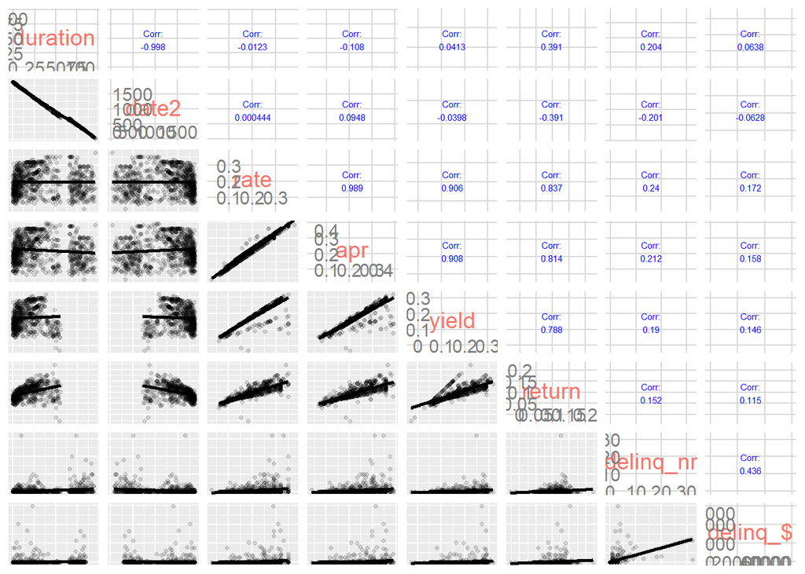

Durantion vs Date, Rate vs APR, Rate vs Yield (or Return) and Delinquency number vs delinquency amount all are highly to marginally highly correlated. We may consider choosing fewer variables, namely “duration”, “rate” and “delinq_nr” only for now on.

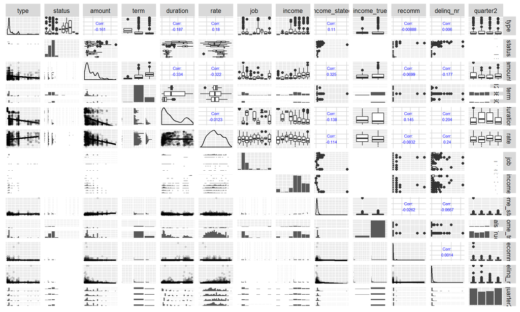

Amount is not strongly correlated with explanatory variables. However, it seems that the higher the amount, the lower is its duration in months. Loans of different status types also have different amounts, without a clear trend, but the duration of loans seem to be higher for charged-off, completed or defaulted loans.

## Loan amount

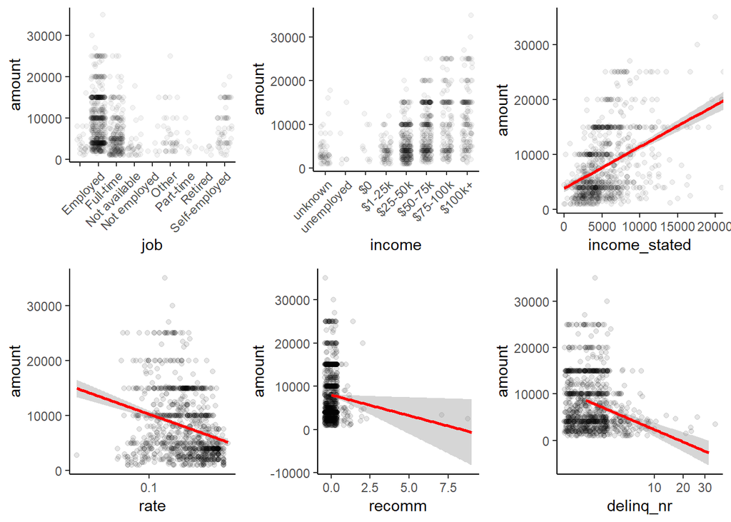

People with more income, probably have better jobs, so that is probably why larger amounts or at least more loans are assigned to people with full-time jobs or employments. The higher the income, the larger is the loan, but usually with lower rates. Recommendations do not seem to influence loan amount much, compared to delinquencies (negatively).

## Loan duration

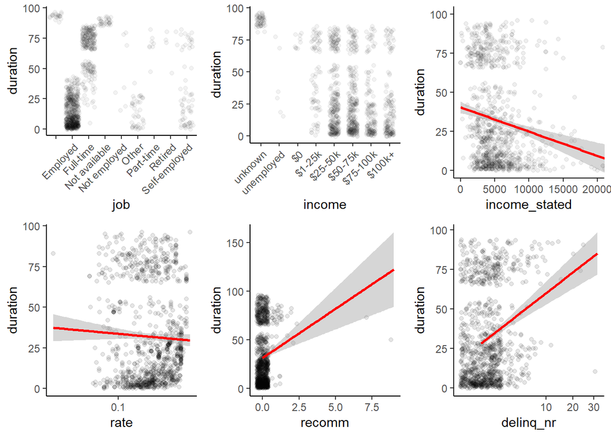

Employed borrowers seem to pay loans more rapidly than full-time borrowers. Part-time and retired people seem to take more time to pay the loan. In addition, self-employed ones have a bi-modal trend (pay rapidly or slowly the loan). Loan payment seem to be independent from income ranges, but looking at where income is a continuous variable, it seems that larger incomes are related to shorter loan durations. The loan duration seem to be independent from borrower rates. Recommendations seem to positively be related to loan duration, for borrowers with at least one recommendation and borrowers with delinquencies seem to pay loans more slowly than non-delinquents.

# Bivariate Analysis Overview

### Pairwise relationships

The total loan amount in dollars may be related with some explanatory variables. It seems that big loans have shorter duration in months. Borrowers that are paid, i.e. have “good” jobs are able to pay more rapidly the loans (usually higher). The loan rates are usually lower for larger loans. Besides, the good or negative information about borrowers, also seem to influence the loan amount and duration.

### Interesting relationships insights

Employed and full-time borrowers, although having expectedly regular incomes, seem to pay loans differently. Loan duration for both groups is very different, and full-time borrowers have longer loan durations.

### Strongest relationship found

The loan amount is negatively related to the loan rate, but positively related to the income stated of the borrower.

# Multivariate Plots Section

Let’s fit a linear regression model, to check whether explanatory variables do indeed explain the variation in loan amount.

### Model fit:

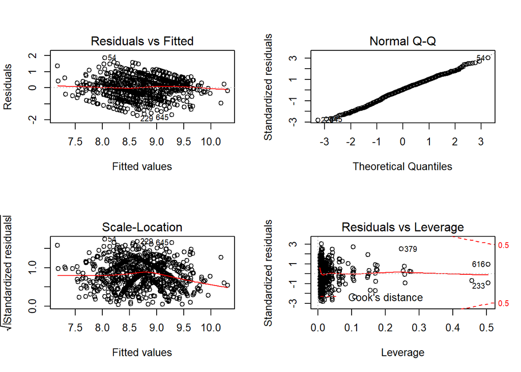

```r
{
# fit model using multiple linear regression
model <- lm(log1p(amount) ~
                            + term
                            + quarter2
                            + duration
                            + rate
                            + job
                            + income_stated
                            + recomm
                            + delinq_nr
              , data = filter(subset, income_true == "True"))
# plot the model fitted values and output
par(mfrow=c(2,2))
plot(model)
}
```

Model summary:

```
##
## Call:
## lm(formula = log1p(amount) ~ +term + quarter2 + duration + rate +
##     job + income_stated + recomm + delinq_nr, data = filter(subset,
##     income_true == "True"))
##
## Residuals:
##      Min       1Q   Median       3Q      Max
## -1.73651 -0.38579  0.03723  0.42288  1.86091
##
## Coefficients:
##                    Estimate Std. Error t value Pr(>|t|)
## (Intercept)       7.850e+00  3.352e-01  23.420  < 2e-16 ***
## term36            7.511e-01  2.364e-01   3.177  0.00154 **
## term60            1.224e+00  2.394e-01   5.114 3.87e-07 ***
## quarter2Q2        3.076e-02  6.116e-02   0.503  0.61515
## quarter2Q3       -1.824e-02  5.999e-02  -0.304  0.76119
## quarter2Q4        6.243e-02  5.633e-02   1.108  0.26805
## duration         -3.154e-03  1.819e-03  -1.734  0.08330 .
## rate             -2.651e+00  3.100e-01  -8.551  < 2e-16 ***
## jobEmployed       3.824e-01  2.094e-01   1.826  0.06818 .
## jobFull-time      2.306e-01  1.643e-01   1.403  0.16082
## jobNot available -6.261e-02  1.947e-01  -0.322  0.74791
## jobNot employed  -6.270e-01  4.661e-01  -1.345  0.17894
## jobOther          2.218e-01  2.324e-01   0.954  0.34022
## jobPart-time      2.221e-01  2.982e-01   0.745  0.45672
## jobRetired       -2.440e-01  3.477e-01  -0.702  0.48302
## jobSelf-employed  4.966e-01  2.501e-01   1.986  0.04735 *
## income_stated     5.653e-05  6.380e-06   8.860  < 2e-16 ***
## recomm           -8.070e-02  4.752e-02  -1.698  0.08984 .
## delinq_nr        -2.255e-02  1.003e-02  -2.248  0.02485 *
## ---
## Signif. codes:  0 '***' 0.001 '**' 0.01 '*' 0.05 '.' 0.1 ' ' 1
##
## Residual standard error: 0.6192 on 878 degrees of freedom
##   (9 observations deleted due to missingness)
## Multiple R-squared:  0.3966, Adjusted R-squared:  0.3842
## F-statistic: 32.06 on 18 and 878 DF,  p-value: < 2.2e-16
```

### Loan amount vs. Income rate

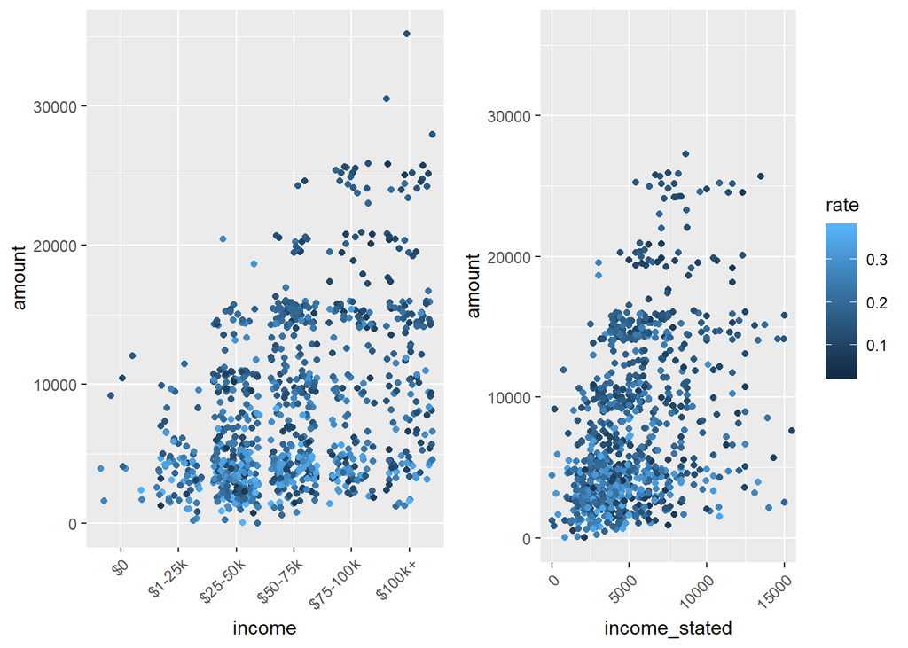

Higher rates are found in small loans, mostly for borrowers with mid-size income.

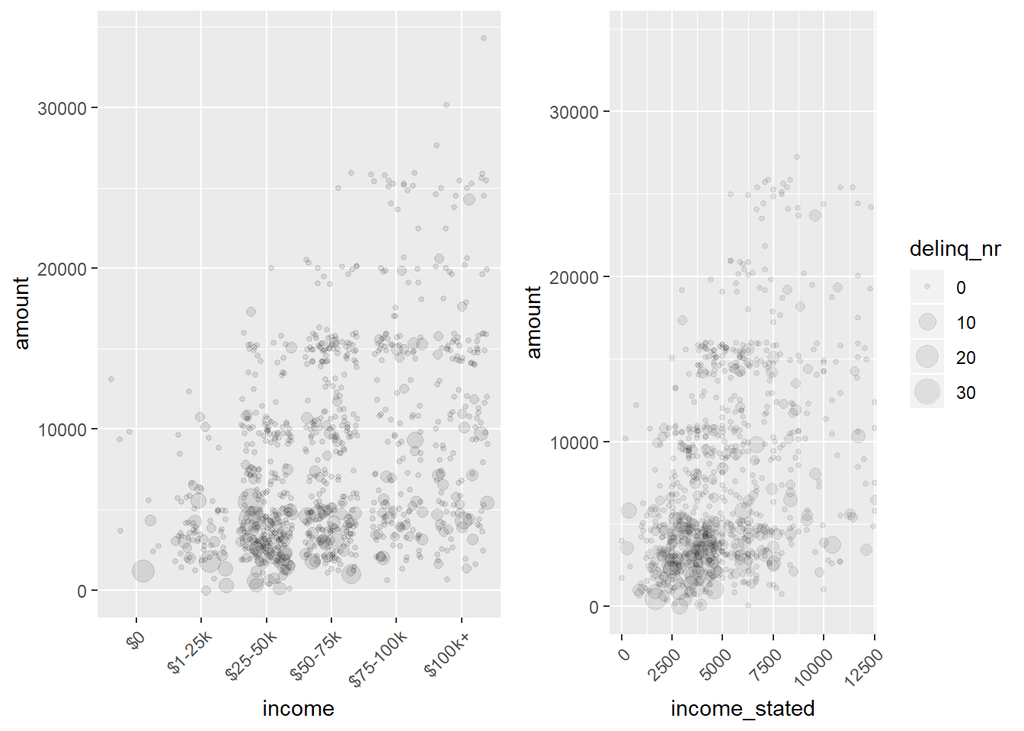

Larger loans seem to be given for people with less delinquencies. But, notice that some high-income borrowers also have large delinquencies.

### Loan Amount vs. duration

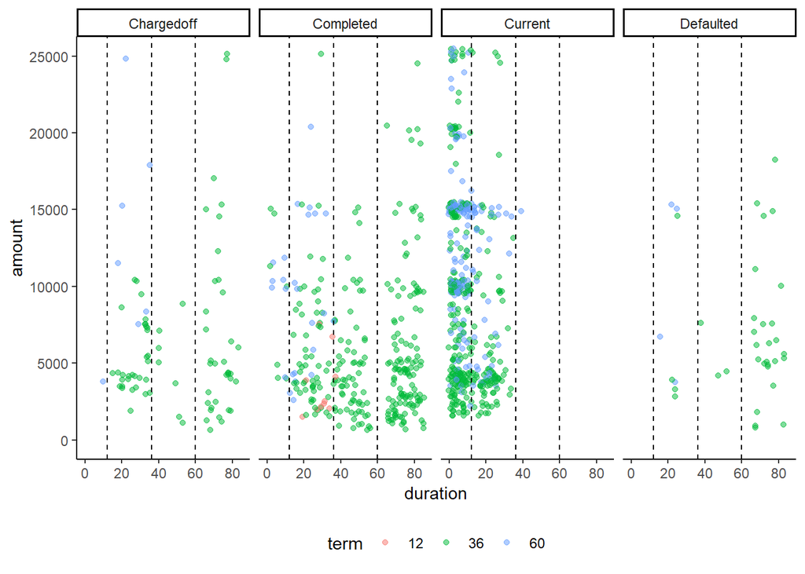

Defaulted loans were mostly over 60 months, although they should have been paid in 36 Charged-off loans were also above the planned time. Most completed loans overpassed the planned duration terms, but not usually for 60-month term loans.

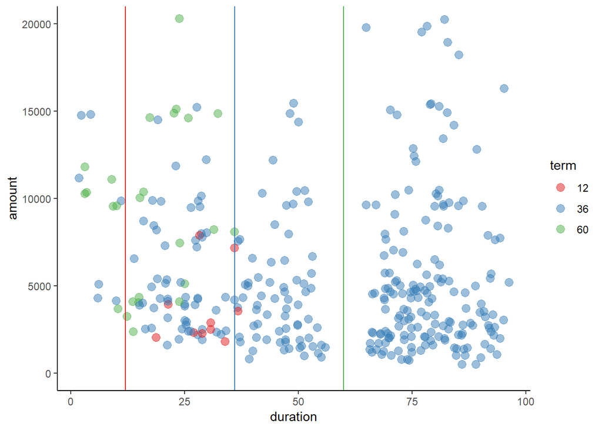

For completed loans, most 36-month (and all 12-month!) loans were above the planned duration. Loans of small- and mid-term were usually paid after the planned deadline (12 and 36 months, respectively), whereas long-term loans were paid much earlier than they should. The loan amount was usually small for 12-month loans, but for 36-month they were very variable, and usually paid much later (after 50 months or so).

### Loan amount vs. term (+ employment and duration)

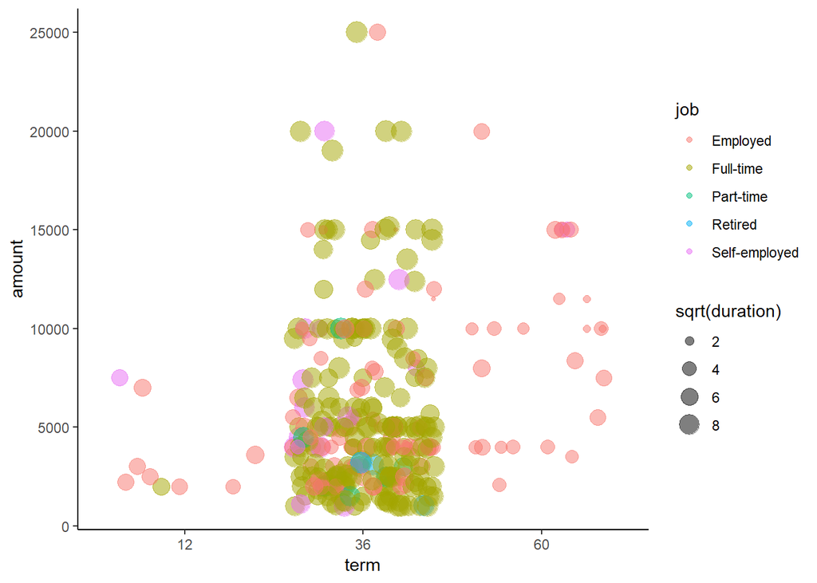

For all types of employment

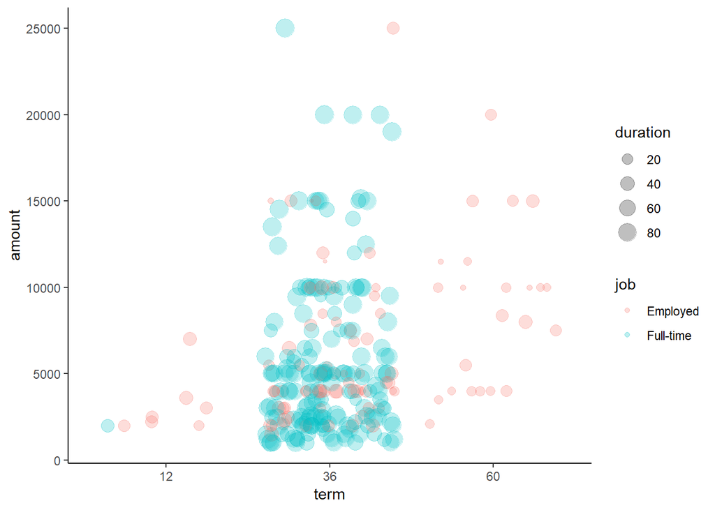

Only for full-time or employed borrowers

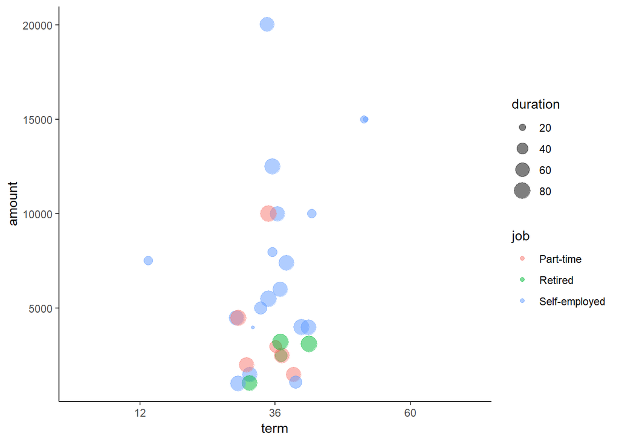

Only for part-time, retired or self-employed borrowers.

Observation: 36-month term loans seem to be by far the preferred option among all borrowers with different employment types. Part-time and retired borrowers usually take smaller loans, but employed borrowers took all types of loans (although mostly 36-moth term) and paid their loans more rapidly (short durations).

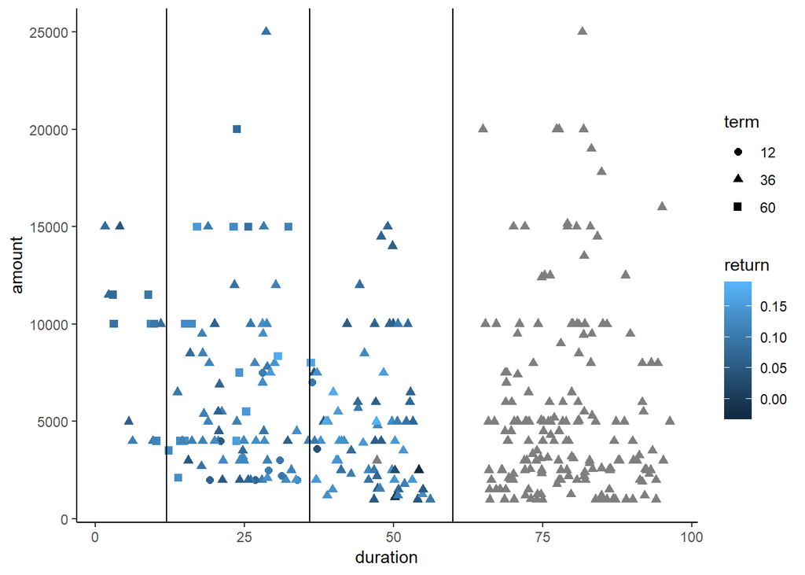

For the completed loans under 50 months, higher returns seem to concentrate on larger loans after 25 months. Largest loans do not have the largest returns. Note that after 2009 (durations over 60 months), there is no information on lender return. In this regard is the dataset incomplete.

### Regional differences: Borrower state vs. amount, income, rate and duration

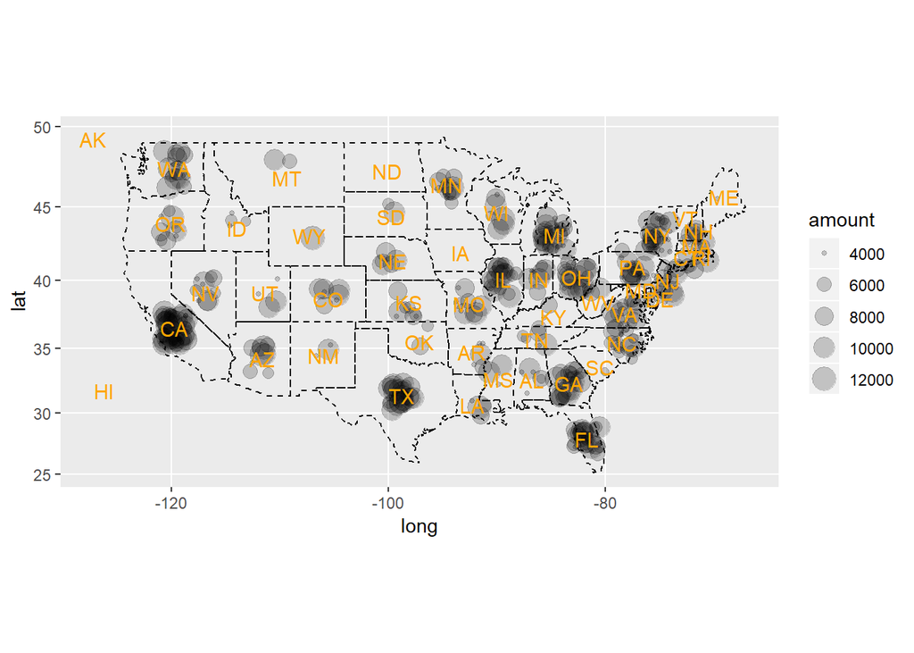

Taking an average loan (>4000 and <12000), we notice that the distribution of loans overall in US does not seem clearly biased. We find large and small loans in different states, but the majority seems to be concentrated on the east side (except for California).

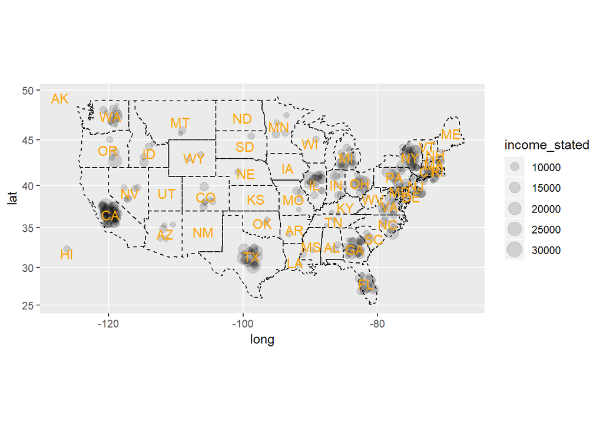

Borrowers with large stated incomes were mostly found also in the east coast. But, we notice thar there are some exceptions, such as in “WA”, “CO” or “TX.

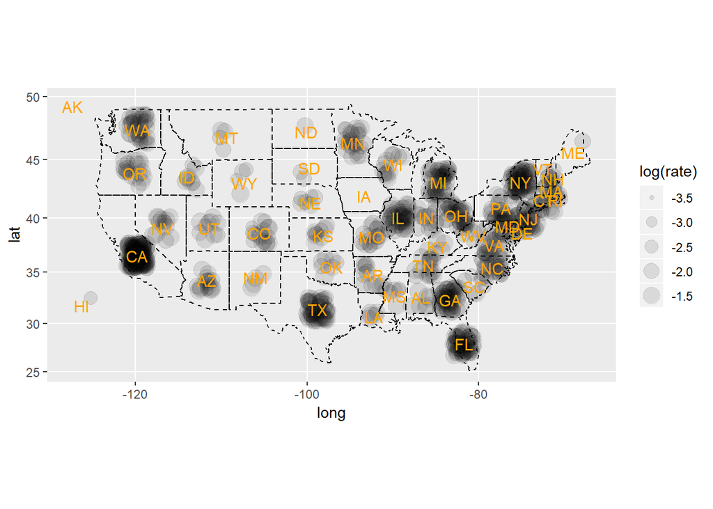

Loan rate does not seem to be influenced by US state.

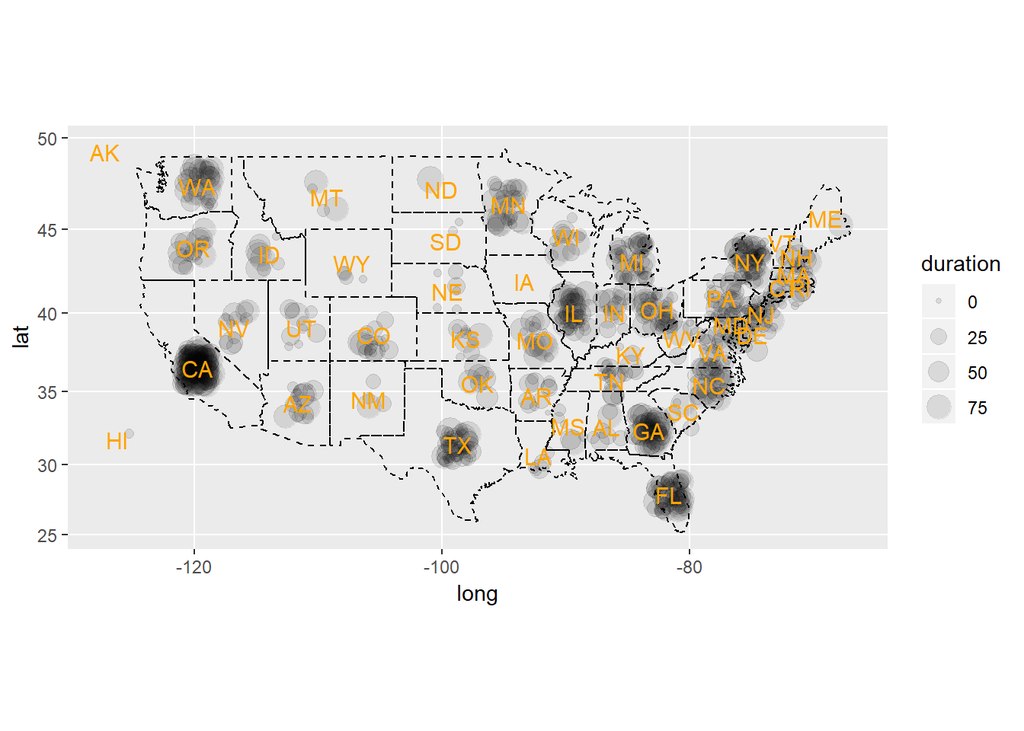

When looking at the distribution over geographic scales, we notice that loans were relatively well distributed regarding duration, rate, and even amount (partially). Income_stated seem to be higher on the east cost and most observations on the data as well.

# Multivariate Analysis

### Interesting or surprising interactions between features

1. For example, I would expect that larger loan amounts would provide higher returns for the lender, but this was not the case.
2. Additionally, I observed that actually in several occasions, loans were not paid in their planned term, but instead much later.
3. Finally, when we look at the duration of the loans, we notice a big gap around 60 months (when 60-month term loans should have been at last paid). This ca. 10-month gap seems to me intriguing and it would be needed perhaps more information on other variables to see what is going on. One possible indication is the financial crisis of early 2009 ( [Global financial crisis in 2009](https://en.wikipedia.org/wiki/Global_financial_crisis_in_2009) ), which exactly matches the period of the gap in this data.

### Additional information that might explain loans

When we plot loan and borrower characteristics on the map, we see that particular differences emerge, and in some US states there are cases of smaller loans, or shorter durations. For this particular analysis, I merged the data with a R repository data containing coordinates information on US states.

### Strengths and limitations of my model

My models did not account for all possible variables in the data, nor did I use a more strict or robust analysis taking into account model selection. However, this was a short solution for my problem. Additionally, I could have taken another approaches (for example Bayesian) or taken a different subset of the whole dataset. Notice that all my analyses were done in a subsample of 1000 observations.

# Final Plots and Summary

### Loan Amount vs. Borrower income and rate

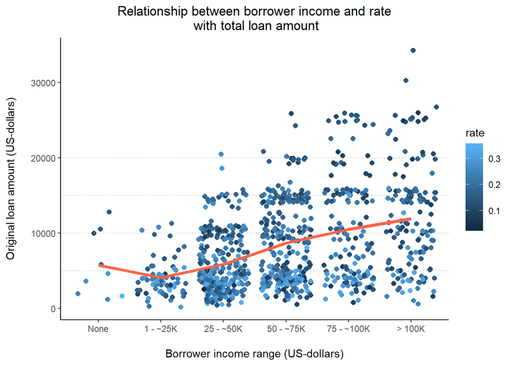

### Loan Amount vs. Borrower delinquency and monthly income

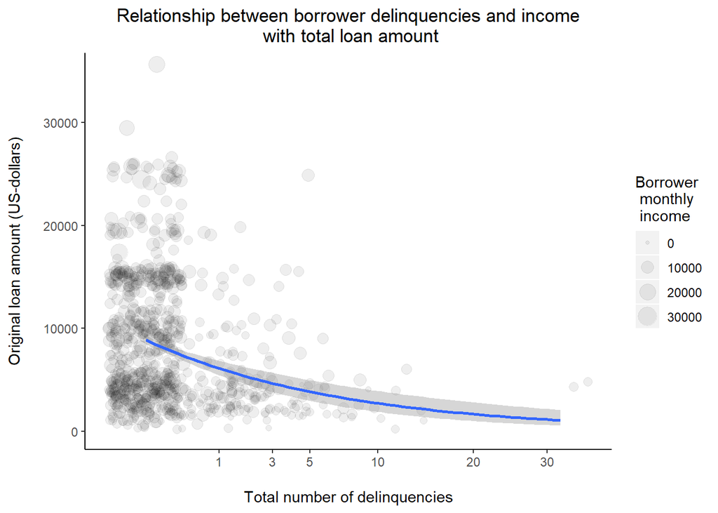

### Description

The number of delinquencies seem to be exponentially related to the loan amount. In other words, very few delinquencies in a borrower profile already drastically affect their ability to take large loans. We notice, however, that most borrowers have none or few numbers of delinquencies. Furthermore, the borrower monthly income rate seem to be higher for those with few delinquencies and who also take larger loans. This makes totally sense, since we would expect people that are more reliable to also be the ones that borrow more money. People with more money (or income) would also be less prone to commit delinquencies too. If they have “good” jobs, one would expect they would not have problems paying back the loans.

### Loan Amount vs. Loan duration and term, and Lender return

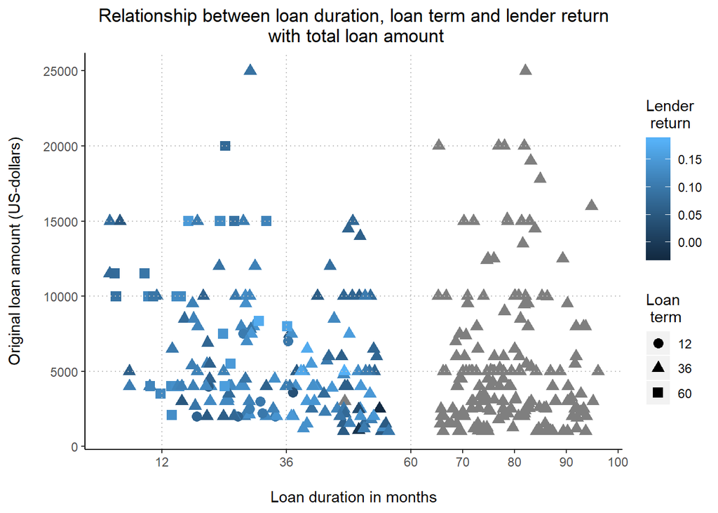

### Description

For all completed loans, we observe that in several cases the terms were lower than their actual duration, which means that most borrowers paid their debit only after their original planned schedule. Lender return not necessarily is higher for larger loans or longer durations. It seems though that the smallest returns were from 36-month loans below 10,000 that overpassed their schedule.

# Reflection

The Exploratory Data Analysis (EDA) on this dataset showed different results. Overall we notice that loan amounts take rounded values, but were commonly under 10,000 dollars. Borrowers with regular mid-size income made the bulk of the data, but we observed that the larger the income, the better is the loan offer (lower rate) and larger is the loan. Most borrowers did not paid loans in the planned time, but later instead, and except for 60-month term loans. Moreover, I found other interesting patterns in the data, for example the fact that borrowers with “dirty profiles” (delinquency occurences) could be detected as having lower loans.

Of course, there are many different alternative ways to analyze this dataset. Most importantly, is to first have a couple of questions that might direct the analysis, given that this dataset has several variables that might give us different information on the data. Besides, analyzing all variables at once is overwhelming and certainly very complex and difficult.